# R Code for Portfolio Optimization Chapter 13 – Index Tracking Portfolios

Daniel P. Palomar (2025). [Portfolio Optimization: Theory and Application.](https://portfoliooptimizationbook.com/) Cambridge University Press.

Last update: March 10, 2025

# Loading packages

First load the packages used in the examples:

```r
# basic finance
library(xts)                    # to manipulate time series of stock data
library(portfolioBacktest)      # to conduct backtests
library(pob)                    # book package with financial data
library(quantmod)               # to download market data from the Internet

# plotting
library(ggplot2)                # for nice plots
library(RcppRoll)               # fast rolling means (roll_meanr)

# optimization
library(quadprog)
library(CVXR)
library(sparseIndexTracking)    # to design index tracking portfolios
library(TRexSelector)           # T-Rex method for sparse regression with FDR control
```

# What is index tracking?

Tracking of the S&P 500 index by the SPDR S&P 500 ETF:

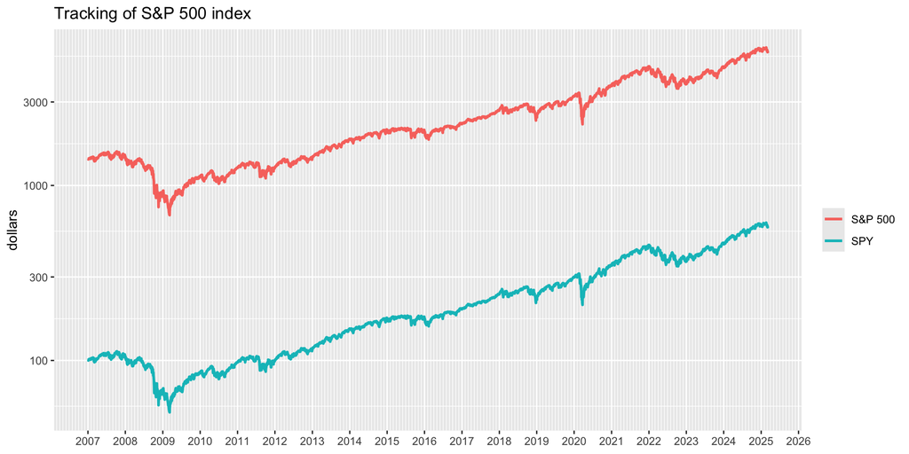

```r
# get data from Yahoo!Finance
library(quantmod)
SP500_prices  <- Ad(getSymbols("^GSPC", from = "2007-01-01", auto.assign = FALSE))
SPY_prices  <- Ad(getSymbols("SPY", from = "2007-01-01", auto.assign = FALSE))
SP500_SPY_prices <- cbind(SP500_prices, SPY_prices)
colnames(SP500_SPY_prices) <- c("S&P 500", "SPY")

ggplot(fortify(SP500_SPY_prices, melt = TRUE), aes(x = Index, y = Value, color = Series)) +
  geom_line(linewidth = 1.0) +
  scale_y_log10() +
  scale_x_date(date_breaks = "1 year", date_labels = "%Y", date_minor_breaks = "1 month") +
  theme(legend.title = element_blank()) +
  labs(title = "Tracking of S&P 500 index", x= NULL, y = "dollars")
```

# Sparse index tracking

Sparse index tracking is a type of sparse regression problem formulated as
$$\begin{array}{ll}
\underset{\w}{\textm{minimize}} & \frac{1}{T}\left\|\bm{r}^\textm{b} - \bm{X}\w\right\|^2_2 + \lambda \|\w\|_0\\
\textm{subject to} & \w \in \mathcal{W},
\end{array}$$
where the matrix $\bm{X}$ contains the returns of the constituent assets, the vector $\bm{r}^\textm{b}$ contains the returns of the index to replicate, the parameter $\lambda$ controls the level of sparsity in the portfolio, and $\mathcal{W}$ is the constraint set which could be $\{\w \mid \bm{1}^\T\w=1, \w\ge\bm{0} \}$.

We define some auxiliary functions:

```r
colCumProd <- function(X) {
  if (!is.xts(X))
    stop("Argument has to be an xts object.")
  xts(apply(X, 2, cumprod), index(X))
}

colCumSum <- function(X) {
  if (!is.xts(X))
    stop("Argument has to be an xts object.")
  xts(apply(X, 2, cumsum), index(X))
}

list2xts <- function(list, names = NULL) {
    n <- length(list)
    res <- NULL
    for (i in seq(n)) res <- cbind(res, list[[i]])
    res <- xts(res, index(list[[1]]))
    if (is.null(names))
      colnames(res) <- sapply(list, colnames)
    else
      colnames(res) <- names
    return(res)
}
```

To design sparse tracking portfolios, we can simply use the R package `spIndexTrack`. For completeness, here we have the simple iterative code based on the MM algorithm:

```r
library(quadprog)

# Recall that quadprog::solve.QP() solves:
#
#   minimize     -d'*x + 0.5*x'*D*x
#   subject to   A'*x =/>= b
#
sparse_tracking_via_MM <- function(X, r, lambda, w0 = NULL, max_iter = 5, thres = 1e-9, p = 1e-3, u = 1, verbose = FALSE) {
  T <- nrow(X)
  N <- ncol(X)
  X <- as.matrix(X)
  r <- as.matrix(r)

  # MM loop
  if (is.null(w0))
    w0 <- rep(1/N, N)
  w <- w0
  if (verbose)
    obj_value <- (1/T)*norm(r - X %*% w, "2")^2 + lambda * sum(log(1 + abs(w)/p)/log(1 + u/p))
  k <- 1
  while (k <= max_iter) {
    d <- 1/(log(1 + u/p)*(p + abs(w)))
    w_prev <- w
    # # Using CVXR:
    # w <- Variable(N)
    # prob <- Problem(Minimize((1/T)*sum((r - X %*% w)^2) + lambda * t(d) %*% w),
    #                 constraints = list(w >= 0, w <= 1, sum(w)==1))
    # result <- solve(prob)
    # w <- as.vector(result$getValue(w))
    # Using quadprog:
    D <- 2* (1/T) * t(X) %*% X
    D <- D + 1e-8*mean(diag(D))*diag(N)
    dd <- (2/T)* as.vector(t(X) %*% r) - lambda*d
    tA  <- rbind(rep(-1, N), diag(N))  # sum(w) = 1 (-sum(w) >= -1) and w >= 0
    b   <- c(-1, rep(0, N))
    w <- tryCatch(solve.QP(Dmat = D, dvec = dd, Amat = t(tA), bvec = b, meq = 1)$solution,
                  warning = function(w) {if (verbose) message(w); return(NULL)},
                  error   = function(e) {if (verbose) message(e); return(NULL)})
    if (verbose)
      obj_value <- c(obj_value, (1/T)*norm(r - X %*% w, "2")^2 + lambda * sum(log(1 + abs(w)/p)/log(1 + u/p)))

    if(norm(w - w_prev, "2")/norm(w_prev, "2") < 1e-3) break
    k <- k + 1
  }
  # thresholding
  w[w < thres] <- 0
  w <- w / sum(w)
  if (!verbose)
    return(w)
  else
    return(list(w = w, obj_value = obj_value))
}
```

## Fixed versus time-varying portfolio

The tracking error (TE) of a fixed portfolio $\w_t=\w$ is
$$\textm{TE} = \frac{1}{T}\left\|\bm{r}^\textm{b} - \bm{X}\w\right\|^2_2,$$
where $\bm{X} \in \R^{T\times N}$ is the matrix containing the $T$ return vectors $\bm{r}_t$ of the $N$ constituent assets along the rows and $\bm{r}^\textm{b} \in \R^{T}$ is the vector containing the $T$ returns of the index.

Now, it the portfolio is not rebalanced, it will naturally evolve over time as
$$\w_t = \frac{\w_{t-1} \odot \left(\bm{1} + \bm{r}_t\right)}{\w_{t-1}^\T \left(\bm{1} + \bm{r}_t\right)} \approx \w_{0} \odot \bm{\alpha}_t,$$
where $\w_{0}$ is the initial portfolio and
$$\bm{\alpha}_t = \prod_{t'=1}^{t}\frac{\bm{1} + \bm{r}_{t'}}{1 + r_{t'}^\textm{b}}$$
denotes weights based on the cumulative returns.The resulting tracking error can be conveniently written as
$$\textm{TE}^\textm{time-varying} = \frac{1}{T}\left\|\bm{r}^\textm{b} - \tilde{\bm{X}}\w\right\|^2_2,$$
where now $\tilde{\bm{X}}$ contains the weighted returns $\tilde{\bm{r}}_t = \bm{r}_t \odot \bm{\alpha}_{t-1}$ along the rows and $\w$ denotes the initial portfolio $\w_0$.

The code to compute $\bm{\alpha}_{t}$ is straightforward:

```r
compute_alpha <- function(X, r) {
  X_cum <- colCumProd(1 + X)
  r_cum <- colCumProd(1 + r)
  alpha <- X_cum / as.vector(r_cum)
  alpha_lagged <- lag(alpha)
  alpha_lagged[1, ] <- 1
  return(list(alpha             = alpha,
              alpha_lagged      = alpha_lagged,
              last_alpha_lagged = as.vector(last(alpha_lagged)),
              X_tilde           = X * alpha_lagged))
}
```

We now perform a backtest to assess the tracking error over time with $K=20$ active assets under the approximation (or assumption) of a fixed portfolio $\w$ and with the more accurate approximation of a time-varying portfolio, which shows improved results.

```r
library(pob)
library(sparseIndexTracking)
library(RcppRoll)  # fast rolling means (roll_meanr)
data(SP500_2015to2020)
T <- nrow(SP500_2015to2020$stocks)  # ["::2020-02", ] excluded the COVID19 crisis
N <- ncol(SP500_2015to2020$stocks)
T_trn <- 2*252


tracking_using_plain_returns_wfixed <- function(dataset, ...) {
  X <- dataset$prices/lag(dataset$prices)[-1] - 1
  r <- dataset$index/lag(dataset$index)[-1] - 1
  #spIndexTrack(X, r, lambda = 7e-7)
  sparse_tracking_via_MM(X, r, lambda = 5e-7, max_iter = 10)
}

tracking_using_plain_returns_wt <- function(dataset, ...) {
  X <- dataset$prices/lag(dataset$prices)[-1] - 1
  r <- dataset$index/lag(dataset$index)[-1] - 1
  alpha <- compute_alpha(X, r)

  # design portfolio
  #w0 <- spIndexTrack(X_cumweighted, r, lambda = 8e-7, p_neg_exp = 5, max_iter = 100) # either 8e-7 or 8.5e-7
  w0 <- sparse_tracking_via_MM(alpha$X_tilde, r, lambda = 5e-7, max_iter = 10)
  w <- w0 * alpha$last_alpha_lagged
  return(w/sum(w))
}


# perform single backtest
bt <- portfolioBacktest(list("Assuming fixed portfolio"        = tracking_using_plain_returns_wfixed,
                             "Assuming time-varying portfolio" = tracking_using_plain_returns_wt),
                        dataset_list = list("dataset1" = list("prices" = SP500_2015to2020$stocks,
                                                              "index"  = SP500_2015to2020$index)),
                        benchmarks = c("index"),
                        lookback = T_trn, optimize_every = 6*21, rebalance_every = 6*21)
```

```
Backtesting 2 portfolios over 1 datasets (periodicity = daily data)...
```

```
Backtesting benchmarks...
```

```r
# make sure there was no error in the backtest
listPortfoliosWithFailures(bt)
num_pf <- length(bt)
bt <- bt[c(num_pf, 1:(num_pf-1))]  # move SP500 to the first position
bt <- lapply(bt, function(pf) {pf$dataset1$X_lin <- NULL; return(pf)})  # reduce object size
```

We can then plot the tracking error and cardinality over time:

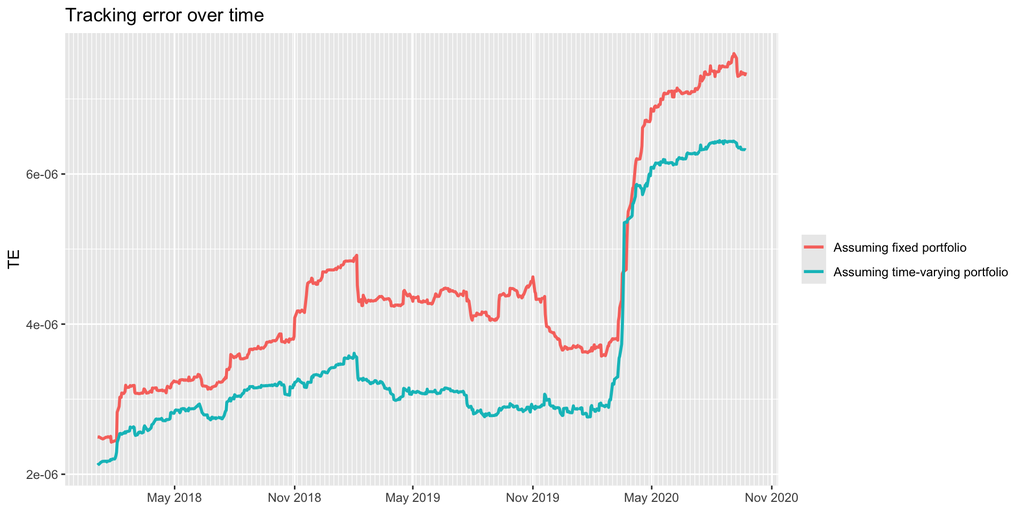

```r
# # plot wealth
# B0 <- as.numeric(SP500_2015to2020$index[T_trn, ])
# price_all <- B0 * list2xts(lapply(bt, function(bt_single) bt_single$dataset1$wealth), names = names(bt))
# ggplot(fortify(price_all, melt = TRUE), aes(x = Index, y = Value, col = Series)) +
#   geom_line(linewidth = 1) +
#   scale_x_date(date_breaks = "6 months", date_labels = "%b %Y", date_minor_breaks = "1 week") +
#   theme(legend.title = element_text()) + labs(color = "Portfolio") +
#   labs(title = "Tracking of S&P 500 index", x= NULL, y = "dollars")


#
# plot smoothed TE
#
ret_all <- list2xts(lapply(bt, function(bt_single) bt_single$dataset1$return), names = names(bt))
TE_inst <- (ret_all[, -1] - as.vector(ret_all[, 1]))^2
TE_smooth <- xts(roll_meanr(as.matrix(TE_inst), n = 252, fill = NA), index(TE_inst))
TE_smooth <- na.omit(TE_smooth)

ggplot(fortify(TE_smooth, melt = TRUE), aes(x = Index, y = Value, color = Series)) +
  geom_line(linewidth = 1) +
  theme(legend.title = element_blank()) +
  scale_x_date(date_breaks = "6 months", date_labels = "%b %Y", date_minor_breaks = "1 week") +
  labs(title = "Tracking error over time", x= NULL, y = "TE")
```

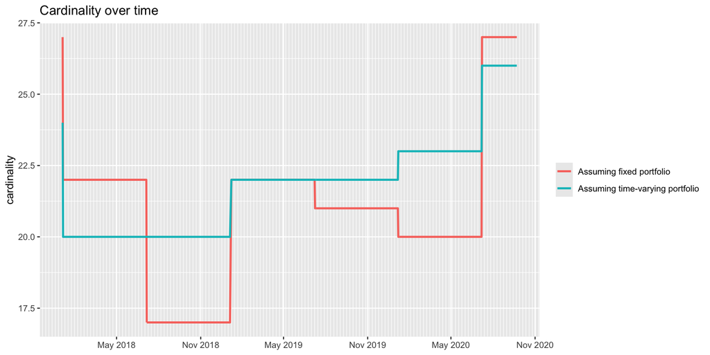

```r
#
# plot cardinality
#
cardinality <- list2xts(lapply(bt[-1], function(bt_single) xts(rowSums(bt_single$dataset1$w_bop > 1e-5), index(bt_single$dataset1$w_bop))), names = names(bt[-1]))
cardinality <- cardinality[index(TE_smooth), ]
ggplot(fortify(cardinality, melt = TRUE), aes(x = Index, y = Value, col = Series)) +
  geom_line(linewidth = 1) +
  scale_x_date(date_breaks = "6 months", date_labels = "%b %Y", date_minor_breaks = "1 week") +
  theme(legend.title = element_blank()) +
  labs(title = "Cardinality over time", x= NULL, y = "cardinality")
```

```r
t(rbind("TE"          = colMeans(TE_inst),
        "cardinality" = colMeans(cardinality)))
```

```
                                          TE cardinality
Assuming fixed portfolio        4.626860e-06    20.92993
Assuming time-varying portfolio 3.712547e-06    21.76642
```

## Plain versus cumulative returns

Minimizing errors in period-by-period returns does not guarantee better long-term cumulative return tracking, as return errors can accumulate unevenly over time. To control long-term cumulative return deviations, the error measure should use long-term or cumulative returns. However, for short-term hedging, period-by-period return tracking is essential, as outperformance is not the objective.

The price error can be measured by the tracking error in terms of the cumulative returns as
$$\textm{TE}^\textm{cum} = \frac{1}{T}\left\|\bm{r}^\textm{b,cum} - \bm{X}^\textm{cum}\w\right\|^2_2,$$
where $\bm{X}^\textm{cum}$ (similarly $\bm{r}^\textm{b,cum}$) denotes the cumulative returns, whose rows can be obtained as
$$\bm{r}^\textm{cum}_t \approx \sum_{t'=1}^{t}\bm{r}_{t'}.$$

We now perform a backtest to assess the tracking error over time using plain returns and cumulative returns:

```r
library(pob)
library(sparseIndexTracking)
library(RcppRoll)  # fast rolling means
data(SP500_2015to2020)
T <- nrow(SP500_2015to2020$stocks)  # ["::2020-02", ] exclused the COVID19 crisis
N <- ncol(SP500_2015to2020$stocks)
T_trn <- 2*252


tracking_using_plain_returns_wfixed <- function(dataset, ...) {
  X <- dataset$prices/lag(dataset$prices)[-1] - 1
  r <- dataset$index/lag(dataset$index)[-1] - 1
  sparse_tracking_via_MM(X, r, lambda = 5e-7, max_iter = 10)
}

tracking_using_cumreturns_wfixed <- function(dataset, ...) {
  X <- dataset$prices/lag(dataset$prices)[-1] - 1
  r <- dataset$index/lag(dataset$index)[-1] - 1
  sparse_tracking_via_MM(X = colCumSum(X),
                         r = colCumSum(r),
                         lambda = 20e-7, max_iter = 10)
}

tracking_using_cumreturns_wt <- function(dataset, ...) {
  X <- dataset$prices/lag(dataset$prices)[-1] - 1
  r <- dataset$index/lag(dataset$index)[-1] - 1
  alpha <- compute_alpha(X, r)
  w0 <- sparse_tracking_via_MM(X = colCumSum(alpha$X_tilde),
                               r = colCumSum(r), lambda = 15e-7, max_iter = 10)
  w <- w0 * alpha$last_alpha_lagged
  return(w/sum(w))
}

# tracking_using_cumprodreturns_wfixed <- function(dataset, ...) {
#   X <- dataset$prices/lag(dataset$prices)[-1] - 1
#   r <- dataset$index/lag(dataset$index)[-1] - 1
#   # sparse_tracking_via_MM(X = colCumProd(1 + X),
#   #                        r = colCumProd(1 + r),
#   #                        lambda = 20e-7, max_iter = 10)
#   sparse_tracking_via_MM(X = exp(colCumSum(X)),
#                          r = exp(colCumSum(r)),
#                          lambda = 20e-7, max_iter = 10)
# }



# perform single backtest
bt <- portfolioBacktest(list("Tracking using plain returns"        = tracking_using_plain_returns_wfixed,
                             "Tracking using cumulative returns"   = tracking_using_cumreturns_wfixed),
                        dataset_list = list("dataset1" = list("prices" = SP500_2015to2020$stocks,
                                                              "index"  = SP500_2015to2020$index)),
                        benchmarks = c("index"),
                        lookback = T_trn, optimize_every = 6*21, rebalance_every = 6*21)
```

```
Backtesting 2 portfolios over 1 datasets (periodicity = daily data)...
```

```
Backtesting benchmarks...
```

```r
# make sure there was no error in the backtest
listPortfoliosWithFailures(bt)
num_pf <- length(bt)
bt <- bt[c(num_pf, 1:(num_pf-1))]  # move SP500 to the first position
bt <- lapply(bt, function(pf) {pf$dataset1$X_lin <- NULL; return(pf)})  # reduce object size
```

We can then plot the price tracked over time:

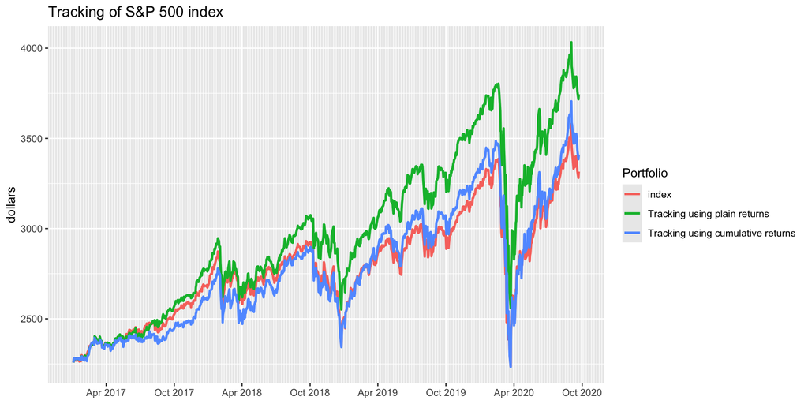

```r
#
# plot wealth
#
B0 <- as.numeric(SP500_2015to2020$index[T_trn, ])
price_all <- B0 * list2xts(lapply(bt, function(bt_single) bt_single$dataset1$wealth), names = names(bt))

ggplot(fortify(price_all, melt = TRUE), aes(x = Index, y = Value, color = Series)) +
  geom_line(linewidth = 1) +
  scale_x_date(date_breaks = "6 months", date_labels = "%b %Y", date_minor_breaks = "1 week") +
  theme(legend.title = element_text()) + labs(color = "Portfolio") +
  labs(title = "Tracking of S&P 500 index", x= NULL, y = "dollars")
```

## Convergence of the iterative reweighted $\ell_1$-norm method

The convergence of the iterative reweighted $\ell_1$-norm method (based on the MM framework) for sparse index tracking is very fast:

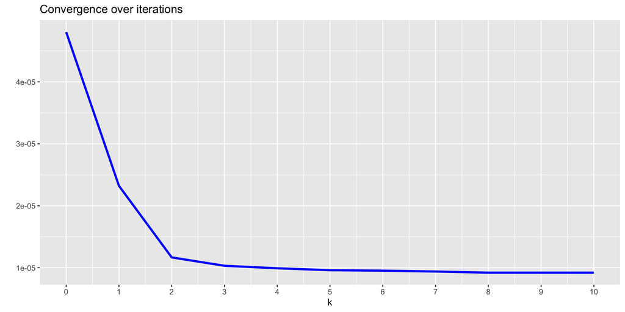

```r
library(pob)
data(SP500_2015to2020)

obj_value <- sparse_tracking_via_MM(X = SP500_2015to2020$stocks/lag(SP500_2015to2020$stocks)[-1] - 1,
                                    r = SP500_2015to2020$index/lag(SP500_2015to2020$index)[-1] - 1,
                                    lambda = 5e-7, max_iter = 10, verbose = TRUE)$obj_value


# plot
last_iter <- length(obj_value) - 1
data.frame("k"               = 0:last_iter,
           "objective value" = obj_value,
           check.names = FALSE) |>
  ggplot(aes(x = k, y = `objective value`)) +
  geom_line(linewidth = 1.2, color = "blue") +
  scale_x_continuous(breaks = 0:last_iter) +
  labs(title = "Convergence over iterations", x= "k", y = "")
```

## Comparison of algorithms

We now compare the tracking of the S&P 500 index based on different tracking methods, namely:

- the naive two-step approach with proportional weights to the index definition;
- the two-step approach with refitted weights;
- the iterative reweighted $\ell_1$-norm method; and
- the MIP formulation (although the computational complexity is too high).

We now perform a backtest to assess the tracking error over time of the S&P 500 index with $K=20$ active assets for different algorithms. The tracking portfolios are computed on a rolling window basis with a lookback period of two years and recomputed every six months.

```r
library(CVXR)
library(pob)
library(sparseIndexTracking)
library(RcppRoll)  # fast rolling means
data(SP500_2015to2020)
T <- nrow(SP500_2015to2020$stocks)
N <- ncol(SP500_2015to2020$stocks)
T_trn <- 2*252


full_tracking <- function(dataset, ...) {
  X <- dataset$prices/lag(dataset$prices)[-1] - 1
  r <- dataset$index/lag(dataset$index)[-1] - 1
  N <- ncol(X)
  # dense portfolio
  b <- Variable(N)
  prob <- Problem(Minimize(sum((as.matrix(r) - as.matrix(X) %*% b)^2)),
                  constraints = list(b >= 0, sum(b)==1))
  result <- solve(prob)
  b <- as.vector(result$getValue(b))
  return(b)
}

two_stage_naive_tracking <- function(dataset, ...) {
  X <- dataset$prices/lag(dataset$prices)[-1] - 1
  r <- dataset$index/lag(dataset$index)[-1] - 1
  N <- ncol(X)
  # first, get the dense portfolio as the reference
  b <- Variable(N)
  prob <- Problem(Minimize(sum((as.matrix(r) - as.matrix(X) %*% b)^2)),
                  constraints = list(b >= 0, sum(b)==1))
  result <- solve(prob)
  b <- as.vector(result$getValue(b))
  # then, keep the K strongest
  idx_Klargest <- sort(b, decreasing = TRUE, index.return = TRUE)$ix[1:K]
  w <- rep(0, N)
  w[idx_Klargest] <- b[idx_Klargest]
  w <- w/sum(w)
  return(w)
}

two_stage_refitted_tracking <- function(dataset, ...) {
  X <- dataset$prices/lag(dataset$prices)[-1] - 1
  r <- dataset$index/lag(dataset$index)[-1] - 1
  N <- ncol(X)
  # first, get the dense portfolio as the reference
  b <- Variable(N)
  prob <- Problem(Minimize(sum((as.matrix(r) - as.matrix(X) %*% b)^2)),
                  constraints = list(b >= 0, sum(b)==1))
  result <- solve(prob)
  b <- as.vector(result$getValue(b))
  # then, keep the K strongest but reoptimizing weights
  idx_Klargest <- sort(b, decreasing = TRUE, index.return = TRUE)$ix[1:K]
  wK <- Variable(K)
  prob <- Problem(Minimize(sum((as.matrix(r) - as.matrix(X[, idx_Klargest]) %*% wK)^2)),
                  constraints = list(wK >= 0, sum(wK)==1))
  result <- solve(prob)
  w <- rep(0, N)
  w[idx_Klargest] <- as.vector(result$getValue(wK))
  return(w)
}


iterative_reweighted_l1_norm_tracking <- function(dataset, ...) {
  X <- dataset$prices/lag(dataset$prices)[-1] - 1
  r <- dataset$index/lag(dataset$index)[-1] - 1
  sparse_tracking_via_MM(X, r, lambda = lmd, max_iter = 10)
}


# perform single backtest
K <- 20
lmd <- 5e-7
bt <- portfolioBacktest(list("Full tracking"                             = full_tracking,
                             "Two-step design with proportional weights" = two_stage_naive_tracking,
                             "Two-step design with refitted weights"     = two_stage_refitted_tracking,
                             "Iterative reweighted $l_1$-norm method"    = iterative_reweighted_l1_norm_tracking),
                        dataset_list = list("dataset1" = list("prices" = SP500_2015to2020$stocks,
                                                              "index"  = SP500_2015to2020$index)),
                        benchmarks = c("index"),
                        lookback = T_trn, optimize_every = 6*21, rebalance_every = 6*21)
```

```
Backtesting 4 portfolios over 1 datasets (periodicity = daily data)...
```

```
Backtesting benchmarks...
```

```r
# make sure there was no error in the backtest
listPortfoliosWithFailures(bt)
num_pf <- length(bt)
bt <- bt[c(num_pf, 1:(num_pf-1))]  # move SP500 to the first position
bt <- lapply(bt, function(pf) {pf$dataset1$X_lin <- NULL; return(pf)})  # reduce object size
```

We can then plot the price, tracking error, and cardinality over time:

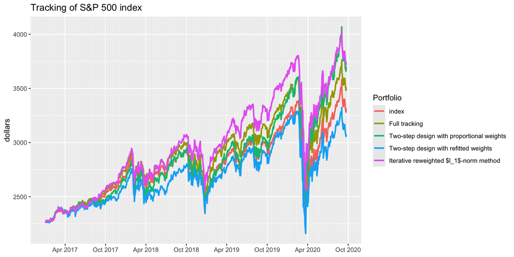

```r
#
# plot wealth
#
B0 <- as.numeric(SP500_2015to2020$index[T_trn, ])
price_all <- B0 * list2xts(lapply(bt, function(bt_single) bt_single$dataset1$wealth), names = names(bt))
ggplot(fortify(price_all, melt = TRUE), aes(x = Index, y = Value, col = Series)) +
  geom_line(linewidth = 1) +
  scale_x_date(date_breaks = "6 months", date_labels = "%b %Y", date_minor_breaks = "1 week") +
  theme(legend.title = element_text()) + labs(color = "Portfolio") +
  labs(title = "Tracking of S&P 500 index", x= NULL, y = "dollars")
```

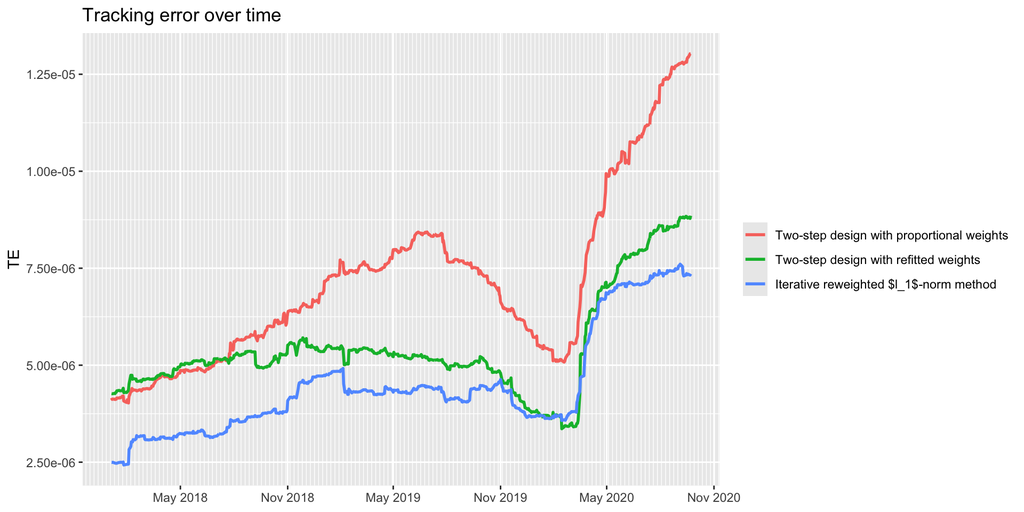

```r
#
# plot smoothed TE
#
ret_all <- list2xts(lapply(bt, function(bt_single) bt_single$dataset1$return), names = names(bt))
TE_inst <- (ret_all[, -1] - as.vector(ret_all[, 1]))^2
TE_smooth <- xts(roll_meanr(as.matrix(TE_inst), n = 252, fill = NA), index(TE_inst))
TE_smooth <- na.omit(TE_smooth)
TE_smooth <- TE_smooth[, -1]   # remove the full tracking
ggplot(fortify(TE_smooth, melt = TRUE), aes(x = Index, y = Value, color = Series)) +
  geom_line(linewidth = 1) +
  theme(legend.title = element_blank()) + #labs(color = "Tracking methods") +
  scale_x_date(date_breaks = "6 months", date_labels = "%b %Y", date_minor_breaks = "1 week") +
  labs(title = "Tracking error over time", x= NULL, y = "TE")
```

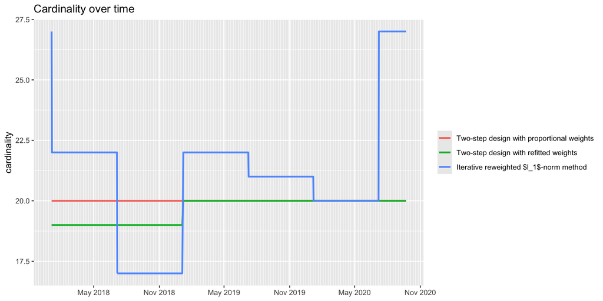

```r
#
# plot cardinality
#
cardinality <- list2xts(lapply(bt[-1], function(bt_single) xts(rowSums(bt_single$dataset1$w_bop > 1e-5), index(bt_single$dataset1$w_bop))), names = names(bt[-1]))
cardinality <- cardinality[index(TE_smooth), ]
cardinality <- cardinality[, -1]   # remove the full tracking
ggplot(fortify(cardinality, melt = TRUE), aes(x = Index, y = Value, col = Series)) +
  geom_line(linewidth = 1) +
  scale_x_date(date_breaks = "6 months", date_labels = "%b %Y", date_minor_breaks = "1 week") +
  theme(legend.title = element_blank()) +
  labs(title = "Cardinality over time", x= NULL, y = "cardinality")
```

```r
t(rbind("TE"          = colMeans(TE_inst),
        "cardinality" = colMeans(cardinality)))
```

[output not shown]

## Comparison of formulations

We consider again the comparison between assuming a fixed portfolio and a time-varying one in the definition of tracking error. More specifically, we now study the tradeoff of tracking error versus cardinality. Indeed, the assumption of the time-varying portfolio is more accurate.

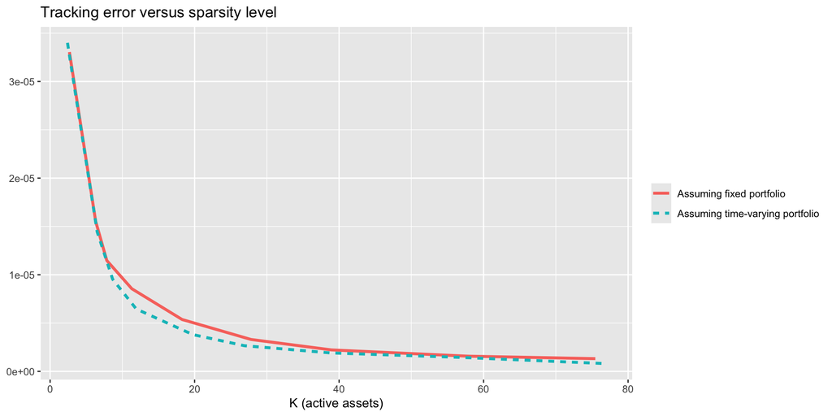

```r
library(pob)
library(sparseIndexTracking)
library(RcppRoll)  # fast rolling means
data(SP500_2015to2020)
T_trn <- 2*252


tracking_using_plain_returns_wfixed <- function(dataset, ...) {
  X <- dataset$prices/lag(dataset$prices)[-1] - 1
  r <- dataset$index/lag(dataset$index)[-1] - 1
  sparse_tracking_via_MM(X, r, lambda = lmd, max_iter = 10)
}

tracking_using_plain_returns_wt <- function(dataset, ...) {
  X <- dataset$prices/lag(dataset$prices)[-1] - 1
  r <- dataset$index/lag(dataset$index)[-1] - 1
  alpha <- compute_alpha(X, r)

  # design portfolio
  w0 <- sparse_tracking_via_MM(alpha$X_tilde, r, lambda = lmd, max_iter = 10)
  w <- w0 * alpha$last_alpha_lagged
  return(w/sum(w))
}


#
# Sweeping loop
#
lmd_sweep <- 1e-5 * c(1, 2, 5, 10, 20, 50, 100, 200, 1000)/300
df <- data.frame()
for (lmd in lmd_sweep) {
  bt <- portfolioBacktest(list("Assuming fixed portfolio"        = tracking_using_plain_returns_wfixed,
                               "Assuming time-varying portfolio" = tracking_using_plain_returns_wt),
                          dataset_list = list("dataset1" = list("prices" = SP500_2015to2020$stocks,
                                                                "index"  = SP500_2015to2020$index)),
                          benchmarks = c("index"),
                          lookback = T_trn, optimize_every = 6*21, rebalance_every = 6*21)
  listPortfoliosWithFailures(bt)
  num_pf <- length(bt)
  bt <- bt[c(num_pf, 1:(num_pf-1))]  # move index to the first position

  # store TE and cardinality
  ret_all <- list2xts(lapply(bt, function(bt_single) bt_single$dataset1$return), names = names(bt))
  TE_all <- colMeans((ret_all[, -1] - as.vector(ret_all[, 1]))^2)
  cardinality_all <- colMeans(list2xts(lapply(bt[-1], function(bt_single)
    xts(rowSums(bt_single$dataset1$w_bop > 1e-5), index(bt_single$dataset1$w_bop))), names = names(bt[-1])))

  df <- rbind(df, data.frame("method"  = names(TE_all),
                             "TE"      = TE_all,
                             "K"       = cardinality_all))
}
rownames(df) <- NULL


# plot
df$method <- factor(df$method, levels = unique(df$method))
ggplot(df, aes(x = K, y = TE, color = method, linetype = method)) +
  geom_line(linewidth = 1.2) +
  theme(legend.title = element_blank()) +
  labs(title = "Tracking error versus sparsity level", x= "K (active assets)", y = NULL)
```

# Enhanced index tracking

We now compare the following tracking error (TE) measures to track the S&P 500 index:

- basic TE:
  $$\textm{TE}(\w) = \frac{1}{T}\left\|\bm{r}^\textm{b} - \bm{X}\w\right\|^2_2;$$
- robust Huberized TE:
  $$\textm{Hub-TE}(\w) = \frac{1}{T}\sum_{t=1}^T \phi^{\textm{hub}}(r_t^\textm{b} - \bm{X}_{t,:}\w),$$
  where
  $$\phi^{\textm{hub}}(x)=\begin{cases}
  x^{2}, & \quad|x|\leq M\\
  M\left(2|x| - M\right), & \quad|x|>M;
  \end{cases}$$
- $\ell_1$-norm TE:
  $$\textm{TE}_1(\w) = \frac{1}{T}\left\|\bm{r}^\textm{b} - \bm{X}\w\right\|_1;$$
- downside risk (DR) error measure:
  $$\textm{DR}(\w) = \frac{1}{T}\left\|\left(\bm{r}^\textm{b} - \bm{X}\w\right)^+\right\|^2_2,$$
  where $(\cdot)^+\triangleq\textm{max}(0,\cdot)$.

We will use the R package `spIndexTrack` to obtain the designs for the backtest:

```r
library(pob)
library(sparseIndexTracking)
data(SP500_2015to2020)
T <- nrow(SP500_2015to2020$stocks)
N <- ncol(SP500_2015to2020$stocks)
T_trn <- 2*252


TE_index_tracking <- function(dataset, ...) {
  X <- dataset$prices/lag(dataset$prices)[-1] - 1
  r <- dataset$index/lag(dataset$index)[-1] - 1

  #w <- spIndexTrack(X, r, lambda = 6e-7, u = 0.5)
  w <- spIndexTrack(colCumSum(X), colCumSum(r), lambda = 150*6e-7, u = 0.5) #100*6e-7 -
  return(w)
}

DR_index_tracking <- function(dataset, ...) {
  X <- dataset$prices/lag(dataset$prices)[-1] - 1
  r <- dataset$index/lag(dataset$index)[-1] - 1

  #w <- spIndexTrack(X, r, lambda = 1.8e-7, u = 0.5, measure = "dr")
  w <- spIndexTrack(colCumSum(X), colCumSum(r), lambda = 190*1.8e-7, u = 0.5, measure = "dr") #200*1.8e-7 - 250*1.8e-7
  return(w)
}

TE1_index_tracking <- function(dataset, ...) {
  X <- dataset$prices/lag(dataset$prices)[-1] - 1
  r <- dataset$index/lag(dataset$index)[-1] - 1

  #w_TE1 <- spIndexTrack(X, r, lambda = 6e-7, u = 0.5)  # initial point
  w_TE1 <- spIndexTrack(colCumSum(X), colCumSum(r), lambda = 100*6e-7, u = 0.5)
  for (k in 1:5) {
    alpha <- as.vector(sqrt(1/(2*abs(r - X %*% w_TE1))))
    #w_TE1 <- spIndexTrack(alpha*X, alpha*r, lambda = 6.5e-4, u = 0.5) # 6 -- 7
    w_TE1 <- spIndexTrack(colCumSum(alpha*X), colCumSum(alpha*r), lambda = 150*6.5e-4, u = 0.5) #100*6.5e-4 -
  }
  return(w_TE1)
}

HubTE_index_tracking <- function(dataset, ...) {
  X <- dataset$prices/lag(dataset$prices)[-1] - 1
  r <- dataset$index/lag(dataset$index)[-1] - 1

  #w <- spIndexTrack(X, r, lambda = 5e-8, u = 0.5, measure = "hete", hub = 1e-4)
  w <- spIndexTrack(colCumSum(X), colCumSum(r), lambda = 50*5e-8, u = 0.5, measure = "hete", hub = 1e-4) # 50*5e-8 - 70*5e-8
  return(w)
}


# perform single backtest
bt <- portfolioBacktest(list("TE based design"     = TE_index_tracking,
                             "Hub-TE based design" = HubTE_index_tracking,
                             "TE_1 based design" = TE1_index_tracking,
                             "DR based design"     = DR_index_tracking),
                        dataset_list = list("dataset1" = list("prices" = SP500_2015to2020$stocks,
                                                              "index"  = SP500_2015to2020$index)),
                        benchmarks = c("index"),
                        lookback = T_trn, optimize_every = 6*21, rebalance_every = 6*21)
```

```
Backtesting 4 portfolios over 1 datasets (periodicity = daily data)...
```

```
Backtesting benchmarks...
```

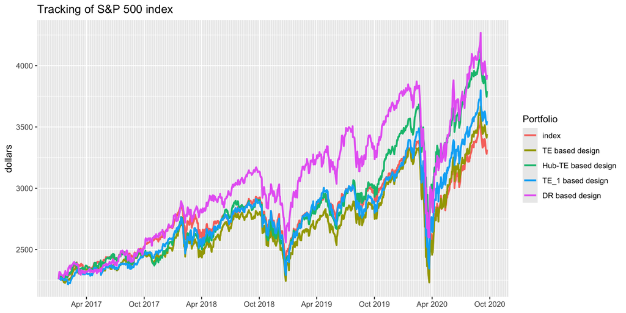

```r
listPortfoliosWithFailures(bt)
bt <- bt[c(length(bt), 1:(length(bt)-1))]  # move SP500 to the first position
bt <- lapply(bt, function(pf) {pf$dataset1$X_lin <- NULL; return(pf)})  # reduce object size


#
# plot wealth
#
B0 <- as.numeric(SP500_2015to2020$index[T_trn, ])
price_all <- B0 * list2xts(lapply(bt, function(bt_single) bt_single$dataset1$wealth), names = names(bt))
ggplot(fortify(price_all, melt = TRUE), aes(x = Index, y = Value, col = Series)) +
  geom_line(linewidth = 1) +
  scale_x_date(date_breaks = "6 months", date_labels = "%b %Y", date_minor_breaks = "1 week") +
  theme(legend.title = element_text()) + labs(color = "Portfolio") +
  labs(title = "Tracking of S&P 500 index", x= NULL, y = "dollars")
```

# Automatic sparsity control

The sparse index tracking formulation includes a regularization term $\lambda \|\w\|_0$ in the objective or as a constraint $\|\w\|_0 \le k$, where the hyper-parameter $\lambda$ or $k$ controls the sparsity level. Adjusting this hyper-parameter allows achieving different points on the error versus sparsity trade-off curve.

In practice, the goal is to choose a proper operating point on this trade-off curve without computing the entire curve. The false discovery rate (FDR), which is the probability of wrongly including a variable, is a key quantity for this decision. Controlling the FDR is the ideal way to decide whether to include a variable.

The T-Rex method, based on “dummy” variables, provides a practical approach for FDR control in sparse index tracking. Instead of tuning the sparsity hyper-parameter, T-Rex automatically selects the assets to include by controlling the FDR, avoiding the selection of irrelevant assets that are highly correlated with already selected ones. The T-Rex method is efficiently implemented in the R package [`TRexSelector`](https://cran.r-project.org/package=TRexSelector) (and soon to come in Python) (Machkour et al., 2022).

We now backest the tracking portfolios obtained from the sparse penalized regression formulation with the FDR-controlling T-Rex method (Machkour et al., 2025). The tracking portfolios are computed on a rolling window basis with a lookback period of two years and recomputed every six months.

```r
library(xts)
library(pob)
library(sparseIndexTracking)
library(RcppRoll)  # fast rolling means
library(quadprog)
data(SP500_2015to2020)
T <- nrow(SP500_2015to2020$stocks)
N <- ncol(SP500_2015to2020$stocks)
T_trn <- 2*252


#
# Define different tracking methods
#
iterative_reweighted_l1_norm_tracking_lmd1e_8 <- function(dataset, ...) {
  X <- dataset$prices/lag(dataset$prices)[-1] - 1
  r <- dataset$index/lag(dataset$index)[-1] - 1
  spIndexTrack(X, r, lambda = 1e-8, u = 0.5)
  #spIndexTrack(colCumSum(X), colCumSum(r), lambda = 150*1e-8, u = 0.5)
}

iterative_reweighted_l1_norm_tracking_lmd1e_7 <- function(dataset, ...) {
  X <- dataset$prices/lag(dataset$prices)[-1] - 1
  r <- dataset$index/lag(dataset$index)[-1] - 1
  spIndexTrack(X, r, lambda = 1e-7, u = 0.5)
  #spIndexTrack(colCumSum(X), colCumSum(r), lambda = 150*1e-7, u = 0.5)
}

iterative_reweighted_l1_norm_tracking_lmd1e_6 <- function(dataset, ...) {
  X <- dataset$prices/lag(dataset$prices)[-1] - 1
  r <- dataset$index/lag(dataset$index)[-1] - 1
  spIndexTrack(X, r, lambda = 1e-6, u = 0.5)
  #spIndexTrack(colCumSum(X), colCumSum(r), lambda = 150*1e-6, u = 0.5)
}

TRex_tracking <- function(dataset, ...) {
  X <- as.matrix(dataset$prices/lag(dataset$prices)[-1] - 1)
  r <- as.vector(dataset$index/lag(dataset$index)[-1] - 1)
  N <- ncol(X)
  X_cum <- apply(X, 2, function(x) cumsum(x))
  r_cum <- cumsum(r)

  # Step 1: T-Rex
  trex_selected <- TRexSelector::trex(X = tail(X, 120), y = tail(r, 120),
  #trex_selected <- TRexSelector::trex(X = X_cum, y = r_cum,
                                      tFDR = 0.3, method = "trex+DA+NN",
                                      verbose = FALSE)$selected_var
  idx_trex <- which(trex_selected == 1)
  K <- length(idx_trex)
  # Step 2: Refit selected assets
  wK <- solve.QP(Dmat = 2 * t(X[, idx_trex]) %*% X[, idx_trex],
                 dvec = 2 * t(X[, idx_trex]) %*% r,
                 Amat = cbind(rep(1, K), diag(K)), bvec = c(1, rep(0, K)), meq = 1)$solution
  w <- rep(0, N)
  w[idx_trex] <- wK
  return(w)
}
```

```r
# perform single backtest
bt <- portfolioBacktest(
  list("Sparse penalized regression (lambda = 1e-8)" = iterative_reweighted_l1_norm_tracking_lmd1e_8,
       "Sparse penalized regression (lambda = 1e-7)" = iterative_reweighted_l1_norm_tracking_lmd1e_7,
       "Sparse penalized regression (lambda = 1e-6)" = iterative_reweighted_l1_norm_tracking_lmd1e_6,
       "T-Rex"         = TRex_tracking),
  dataset_list = list("dataset1" = list("prices" = SP500_2015to2020$stocks,
                                        "index"  = SP500_2015to2020$index)),
  benchmarks = c("index"),
  lookback = T_trn, optimize_every = 6*21, rebalance_every = 6*21)
listPortfoliosWithFailures(bt)
bt <- bt[c(length(bt), 1:(length(bt)-1))]  # move SP500 to the first position
bt <- lapply(bt, function(pf) {pf$dataset1$X_lin <- NULL; return(pf)})  # reduce object size
```

We can then plot the price, tracking error, and cardinality over time. As can be seen, the traditional sparse regression formulation is very sensitive to the choice of the parameter $\lambda$, producing very different results in terms of tracking error and cardinality. On the other hand, the FDR-controlling T-Rex method automatically chooses the appropriate sparsity level without having to tune any parameter. The computational cost of T-Rex is slightly higher than that of the traditional method for a fixed $\lambda$ but lower than the traditional method for a whole range of values for $\lambda$.

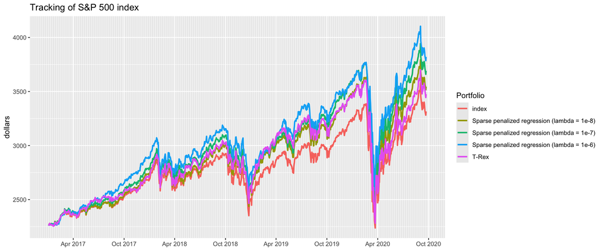

```r
#
# plot wealth
#
B0 <- as.numeric(SP500_2015to2020$index[T_trn, ])
price_all <- B0 * list2xts(lapply(bt, function(bt_single) bt_single$dataset1$wealth), names = names(bt))
ggplot(fortify(price_all, melt = TRUE), aes(x = Index, y = Value, col = Series)) +
  geom_line(linewidth = 1) +
  scale_x_date(date_breaks = "6 months", date_labels = "%b %Y", date_minor_breaks = "1 week") +
  theme(legend.title = element_text()) + labs(color = "Portfolio") +
  labs(title = "Tracking of S&P 500 index", x= NULL, y = "dollars")
```

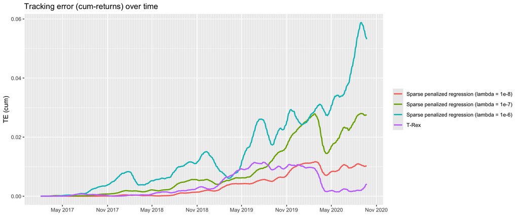

```r
#
# plot smoothed cumulative TE
#
cumTE_inst <- ((price_all[, -1] - as.vector(price_all[, 1]))/B0)^2
cumTE_smooth <- xts(roll_meanr(as.matrix(cumTE_inst), n = 21, fill = NA), index(cumTE_inst))
cumTE_smooth <- na.omit(cumTE_smooth)
ggplot(fortify(cumTE_smooth, melt = TRUE), aes(x = Index, y = Value, color = Series)) +
  geom_line(linewidth = 1) +
  scale_x_date(date_breaks = "6 months", date_labels = "%b %Y", date_minor_breaks = "1 week") +
  theme(legend.title = element_blank()) +
  labs(title = "Tracking error (cum-returns) over time", x= NULL, y = "TE (cum)")
```

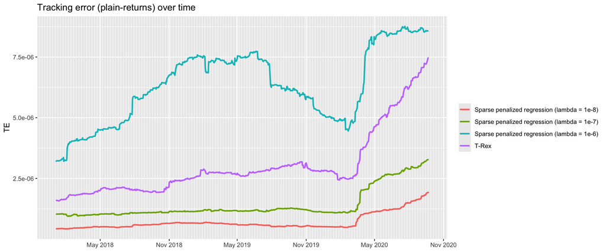

```r
#
# plot smoothed period-by-period TE
#
ret_all <- list2xts(lapply(bt, function(bt_single) bt_single$dataset1$return), names = names(bt))
TE_inst <- (ret_all[, -1] - as.vector(ret_all[, 1]))^2
TE_smooth <- xts(roll_meanr(as.matrix(TE_inst), n = 252, fill = NA), index(TE_inst))
TE_smooth <- na.omit(TE_smooth)
ggplot(fortify(TE_smooth, melt = TRUE), aes(x = Index, y = Value, color = Series)) +
  geom_line(linewidth = 1) +
  scale_x_date(date_breaks = "6 months", date_labels = "%b %Y", date_minor_breaks = "1 week") +
  theme(legend.title = element_blank()) +
  labs(title = "Tracking error (plain-returns) over time", x= NULL, y = "TE")
```

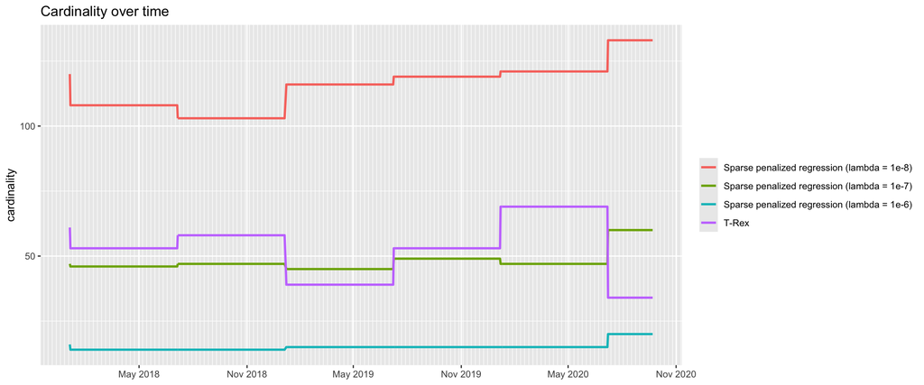

```r
#
# plot cardinality
#
cardinality <- list2xts(lapply(bt[-1], function(bt_single) xts(rowSums(bt_single$dataset1$w_bop > 1e-5), index(bt_single$dataset1$w_bop))), names = names(bt[-1]))
cardinality <- cardinality[index(TE_smooth), ]
ggplot(fortify(cardinality, melt = TRUE), aes(x = Index, y = Value, color = Series)) +
  geom_line(linewidth = 1) +
  scale_x_date(date_breaks = "6 months", date_labels = "%b %Y", date_minor_breaks = "1 week") +
  theme(legend.title = element_blank()) +
  labs(title = "Cardinality over time", x= NULL, y = "cardinality")
```

```r
t(rbind("TE"          = colMeans(TE_inst),
        "cardinality" = colMeans(cardinality)))
```

```
                                                      TE cardinality
Sparse penalized regression (lambda = 1e-8) 9.195354e-07   114.95474
Sparse penalized regression (lambda = 1e-7) 1.712832e-06    47.84088
Sparse penalized regression (lambda = 1e-6) 6.203776e-06    15.02774
T-Rex                                       3.638299e-06    52.80146
```

## References

Machkour, J., Palomar, D. P., and Muma, M. (2025). FDR-controlled portfolio optimization for sparse financial index tracking. In *Proceedings of the IEEE international conference on acoustics, speech, and signal processing (ICASSP)*. Hyderabad, India.

Machkour, J., Tien, S., Palomar, D. P., and Muma, M. (2022). *[TRexSelector: T-rex selector: High-dimensional variable selection & FDR control](https://CRAN.R-project.org/package=TRexSelector)*.